# Medical Appointment No Show Analysis

- Introduction
- Data Wrangling
- Exploratory Data Analysis
- Conclusions

## Introduction

In this analysis, I will be using the medical appointment no show dataset from the Kaggle page. The dataset includes 14 features in total; one feature is the independent variable called **no_show**, and other 13 features are the dependent variables. I won't detail here what each feature stands for as there is already link for it in the project description. Based on the information from the dataset's Kaggle page, my aim will be to answer the following questions in the end of my analysis.

1. What are the characteristics of patients who don't show up to their appointment?
2. Would the day and month of the scheduled appointment reflect on the no show?
3. Would scheduling the appointment way more ahead than the actual appointment be related to more no show?

```python
# Import the necessary libraries to use
import pandas as pd
import numpy as np
import matplotlib.pyplot as plt
import seaborn as sns

# Magic keywords
%matplotlib inline
```

## Data Wrangling

### General Properties

```python
df = pd.read_csv('noshowappointments-kagglev2-may-2016.csv')
df.head(5)
```

|  | PatientId | AppointmentID | Gender | ScheduledDay | AppointmentDay | Age | Neighbourhood | Scholarship | Hipertension | Diabetes | Alcoholism | Handcap | SMS_received | No-show |
| --- | --- | --- | --- | --- | --- | --- | --- | --- | --- | --- | --- | --- | --- | --- |
| 0 | 2.987250e+13 | 5642903 | F | 2016-04-29T18:38:08Z | 2016-04-29T00:00:00Z | 62 | JARDIM DA PENHA | 0 | 1 | 0 | 0 | 0 | 0 | No |
| 1 | 5.589978e+14 | 5642503 | M | 2016-04-29T16:08:27Z | 2016-04-29T00:00:00Z | 56 | JARDIM DA PENHA | 0 | 0 | 0 | 0 | 0 | 0 | No |
| 2 | 4.262962e+12 | 5642549 | F | 2016-04-29T16:19:04Z | 2016-04-29T00:00:00Z | 62 | MATA DA PRAIA | 0 | 0 | 0 | 0 | 0 | 0 | No |
| 3 | 8.679512e+11 | 5642828 | F | 2016-04-29T17:29:31Z | 2016-04-29T00:00:00Z | 8 | PONTAL DE CAMBURI | 0 | 0 | 0 | 0 | 0 | 0 | No |
| 4 | 8.841186e+12 | 5642494 | F | 2016-04-29T16:07:23Z | 2016-04-29T00:00:00Z | 56 | JARDIM DA PENHA | 0 | 1 | 1 | 0 | 0 | 0 | No |

```python
df.info()
```

```
<class 'pandas.core.frame.DataFrame'>
RangeIndex: 110527 entries, 0 to 110526
Data columns (total 14 columns):
 #   Column          Non-Null Count   Dtype
---  ------          --------------   -----
 0   PatientId       110527 non-null  float64
 1   AppointmentID   110527 non-null  int64
 2   Gender          110527 non-null  object
 3   ScheduledDay    110527 non-null  object
 4   AppointmentDay  110527 non-null  object
 5   Age             110527 non-null  int64
 6   Neighbourhood   110527 non-null  object
 7   Scholarship     110527 non-null  int64
 8   Hipertension    110527 non-null  int64
 9   Diabetes        110527 non-null  int64
 10  Alcoholism      110527 non-null  int64
 11  Handcap         110527 non-null  int64
 12  SMS_received    110527 non-null  int64
 13  No-show         110527 non-null  object
dtypes: float64(1), int64(8), object(5)
memory usage: 11.8+ MB
```

First, a couple of observations:

- None of the features have missing values.
- The column names are inconsistent. Sometimes, the feature names are seperated with an underscore; and sometimes, they are seperated with a dash. In addition, some column names are formed from multiple words using the case according to java language.
- **ScheduledDay** and **AppointmentDay** features are not in datetime type.
- **Handcap** feature name doesn't make sense; based on the domain understanding, it stands for handicap.
- **Scholarship** feature name is also confusing, it stands for being on the social welfare program.
- **Hipertension** is wrong, should be **Hypertension**.

Let's see the distribution of the features below to see whether there are any errand entries; or, any inconsistencies.

```python
df.describe()
```

|  | PatientId | AppointmentID | Age | Scholarship | Hipertension | Diabetes | Alcoholism | Handcap | SMS_received |
| --- | --- | --- | --- | --- | --- | --- | --- | --- | --- |
| count | 1.105270e+05 | 1.105270e+05 | 110527.000000 | 110527.000000 | 110527.000000 | 110527.000000 | 110527.000000 | 110527.000000 | 110527.000000 |
| mean | 1.474963e+14 | 5.675305e+06 | 37.088874 | 0.098266 | 0.197246 | 0.071865 | 0.030400 | 0.022248 | 0.321026 |
| std | 2.560949e+14 | 7.129575e+04 | 23.110205 | 0.297675 | 0.397921 | 0.258265 | 0.171686 | 0.161543 | 0.466873 |
| min | 3.921784e+04 | 5.030230e+06 | -1.000000 | 0.000000 | 0.000000 | 0.000000 | 0.000000 | 0.000000 | 0.000000 |
| 25% | 4.172614e+12 | 5.640286e+06 | 18.000000 | 0.000000 | 0.000000 | 0.000000 | 0.000000 | 0.000000 | 0.000000 |
| 50% | 3.173184e+13 | 5.680573e+06 | 37.000000 | 0.000000 | 0.000000 | 0.000000 | 0.000000 | 0.000000 | 0.000000 |
| 75% | 9.439172e+13 | 5.725524e+06 | 55.000000 | 0.000000 | 0.000000 | 0.000000 | 0.000000 | 0.000000 | 1.000000 |
| max | 9.999816e+14 | 5.790484e+06 | 115.000000 | 1.000000 | 1.000000 | 1.000000 | 1.000000 | 4.000000 | 1.000000 |

A couple of immediate observations:

- **Age** has some errand values, -1 is an impossible age value. Similarly, 115 is very unlikely
- **Handcap** is supposed to be a binary feature; but, it does have non binary values such as 4

Let's see the distribution of **Age**.

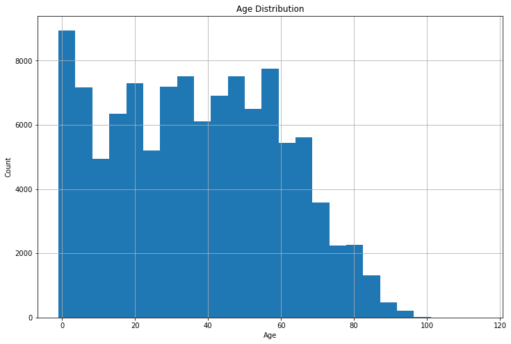

```python
plt.figure(figsize=(12, 8))
df.Age.hist(bins=25)
plt.title('Age Distribution')
plt.xlabel('Age')
plt.ylabel('Count');
```

Considering the age between 0 and 90 would be sufficient to respond our questions; the sample would represent the majority of distribution; hence, we can drop the rows outside of this range.

What are the unique **Handcap** values?

```python
df.Handcap.unique()
```

```
array([0, 1, 2, 3, 4])
```

```python
df.Handcap.value_counts()
```

```
0    108286
1      2042
2       183
3        13
4         3
Name: Handcap, dtype: int64
```

Looks like **Handcap** has 199 non binary values. Based on the dataset description from the Kaggle, this should be a binary feature. The value 2, 3 and 4 could have a special meaning from the provider; or, they could be just incorrect entries. I would just delete these rows so as to be on the safe side.

Let's also see how unique the **ID** features are:

```python
num_unique_pid = df.PatientId.nunique()
num_unique_aid = df.AppointmentID.nunique()
print('Number of unique patient ids are {} and unique appointment ids are {}'.format(num_unique_pid, num_unique_aid))
```

```
Number of unique patient ids are 62299 and unique appointment ids are 110527
```

Looks like the **AppointmentID** column is a primary key column; probably, it won't be giving too much information for answering our questions.

Also, some patients seem like having multiple appointments. Let's see how the number of appointments change per patient.

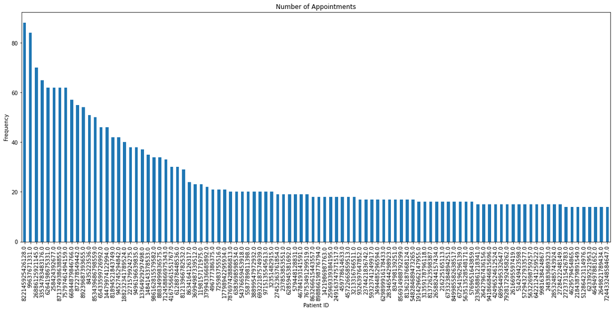

```python
df.PatientId.value_counts().sort_values(ascending=False).head(100).plot(kind='bar', figsize=(20, 8), title='Number of Appointments')
plt.xlabel('Patient ID')
plt.ylabel('Frequency');
```

Here, we see the distribution of the number of appointments per patient for the top 100 most appointment making patients. There are a few patients who makes too many appointments. Let's see the number of patients who make only one appointment.

```python
num_of_appointments = df.PatientId.value_counts()
print(f'Number of patients making single appointment {len(num_of_appointments.loc[num_of_appointments == 1])}')
```

```
Number of patients making single appointment 37920
```

Looks like more than half of the patients made single appointment.

Also, let's check whether string variables have any errant entries.

```python
df.Gender.unique()
```

```
array(['F', 'M'], dtype=object)
```

```python
df.Neighbourhood.sort_values().unique()
```

```
array(['AEROPORTO', 'ANDORINHAS', 'ANTÔNIO HONÓRIO',
       'ARIOVALDO FAVALESSA', 'BARRO VERMELHO', 'BELA VISTA',
       'BENTO FERREIRA', 'BOA VISTA', 'BONFIM', 'CARATOÍRA', 'CENTRO',
       'COMDUSA', 'CONQUISTA', 'CONSOLAÇÃO', 'CRUZAMENTO', 'DA PENHA',
       'DE LOURDES', 'DO CABRAL', 'DO MOSCOSO', 'DO QUADRO',
       'ENSEADA DO SUÁ', 'ESTRELINHA', 'FONTE GRANDE', 'FORTE SÃO JOÃO',
       'FRADINHOS', 'GOIABEIRAS', 'GRANDE VITÓRIA', 'GURIGICA', 'HORTO',
       'ILHA DAS CAIEIRAS', 'ILHA DE SANTA MARIA', 'ILHA DO BOI',
       'ILHA DO FRADE', 'ILHA DO PRÍNCIPE', 'ILHAS OCEÂNICAS DE TRINDADE',
       'INHANGUETÁ', 'ITARARÉ', 'JABOUR', 'JARDIM CAMBURI',
       'JARDIM DA PENHA', 'JESUS DE NAZARETH', 'JOANA D´ARC',
       'JUCUTUQUARA', 'MARIA ORTIZ', 'MARUÍPE', 'MATA DA PRAIA',
       'MONTE BELO', 'MORADA DE CAMBURI', 'MÁRIO CYPRESTE', 'NAZARETH',
       'NOVA PALESTINA', 'PARQUE INDUSTRIAL', 'PARQUE MOSCOSO', 'PIEDADE',
       'PONTAL DE CAMBURI', 'PRAIA DO CANTO', 'PRAIA DO SUÁ', 'REDENÇÃO',
       'REPÚBLICA', 'RESISTÊNCIA', 'ROMÃO', 'SANTA CECÍLIA',
       'SANTA CLARA', 'SANTA HELENA', 'SANTA LUÍZA', 'SANTA LÚCIA',
       'SANTA MARTHA', 'SANTA TEREZA', 'SANTO ANDRÉ', 'SANTO ANTÔNIO',
       'SANTOS DUMONT', 'SANTOS REIS', 'SEGURANÇA DO LAR', 'SOLON BORGES',
       'SÃO BENEDITO', 'SÃO CRISTÓVÃO', 'SÃO JOSÉ', 'SÃO PEDRO',
       'TABUAZEIRO', 'UNIVERSITÁRIO', 'VILA RUBIM'], dtype=object)
```

```python
df['No-show'].unique()
```

```
array(['No', 'Yes'], dtype=object)
```

Looks like there is no unnecessary entry in the string values to correct.

Last, let's check the validity of the range of dates existing in the data.

```python
print(df.AppointmentDay.min(), df.AppointmentDay.max())
```

```
2016-04-29T00:00:00Z 2016-06-08T00:00:00Z
```

```python
print(df.ScheduledDay.min(), df.ScheduledDay.max())
```

```
2015-11-10T07:13:56Z 2016-06-08T20:07:23Z
```

Ranges seem reasonable for both dates. Also, let's do a sanity check whether all the records have reasonable scheduled dates after the appointment dates.

```python
df.loc[df.ScheduledDay >= df.AppointmentDay].AppointmentID.count()
```

```
38568
```

Wow, looks like the majority of the dataset has errant date information. The rows which have **ScheduledDay** before the **AppointmentDay** should be removed.

### Data Cleaning

Based on the general properties of this dataset, I will execute the following steps to clean this dataset:

- I will change the the type of the **ScheduledDay** and **AppointmentDay** column to datetime.
- I will only pick the rows which have a **ScheduledDay** value after the **AppointmentDay** value. These are to correct rows to be used to answer our questions.
- I will remove all the rows with age less than 0 and more than 90. It is impossible to have a negative age and it is extremely unlikely to have someone having an appointment after 90. The representation of the sample wouldn't change much based on the plotted histogram in the previous section.
- I will remove any rows which don't have the values 0 or 1 in **Handcap**. Removing these wouldn't change the results much.
- I will drop the **AppointmentID** column, since this is not a helpful column to answer our questions.
- Last, I will change all the column names. All names will be lowercase; and, all words forming a column name will be seperated by an underscore "_". Also, I will change the column names **Handcap** to **Handicap**, **Hipertension** to **Hypertension** and **Scholarship** to **social_welfare**.

```python
# Creating a clean copy of the original dataset so that we don't keep working on a slice of the original dataset.
# This is better, because the underlying ndarray object might not always update based on the changes made inplace.
clean_df = df.copy(deep=True)
```

#### Step 1: Change Day Column Type

```python
clean_df.AppointmentDay = pd.to_datetime(clean_df.AppointmentDay)
clean_df.ScheduledDay = pd.to_datetime(clean_df.ScheduledDay)
```

#### Step 2: Pick The Rows with Scheduled Day After The Appointment Day

```python
clean_df = clean_df.loc[clean_df.ScheduledDay >= clean_df.AppointmentDay]
```

#### Step 3: Pick The Rows With Age Ranging Between 0 and 90

```python
clean_df = clean_df.query('Age >= 0 and Age <= 90')
```

#### Step 4: Select Rows With Handcap Values 0 Or 1

```python
clean_df = clean_df.query('Handcap == 0 or Handcap == 1')
```

#### Step 5: Drop Unnecessary Column

```python
clean_df.drop('AppointmentID', axis=1, inplace=True)
```

#### Step 6: Change The Column Names

```python
clean_df.rename(columns=lambda x: x.lower().replace('-', '_'), inplace=True)
clean_df.rename(columns={'handcap': 'handicap',
                         'patientid': 'patient_id',
                         'scheduledday': 'scheduled_day',
                         'appointmentday': 'appointment_day',
                         'scholarship': 'social_welfare',
                         'hipertension': 'hypertension'}, inplace=True)
```

#### Step 7: Sanity Check

```python
clean_df.head()
```

|  | patient_id | gender | scheduled_day | appointment_day | age | neighbourhood | social_welfare | hypertension | diabetes | alcoholism | handicap | sms_received | no_show |
| --- | --- | --- | --- | --- | --- | --- | --- | --- | --- | --- | --- | --- | --- |
| 0 | 2.987250e+13 | F | 2016-04-29 18:38:08+00:00 | 2016-04-29 00:00:00+00:00 | 62 | JARDIM DA PENHA | 0 | 1 | 0 | 0 | 0 | 0 | No |
| 1 | 5.589978e+14 | M | 2016-04-29 16:08:27+00:00 | 2016-04-29 00:00:00+00:00 | 56 | JARDIM DA PENHA | 0 | 0 | 0 | 0 | 0 | 0 | No |
| 2 | 4.262962e+12 | F | 2016-04-29 16:19:04+00:00 | 2016-04-29 00:00:00+00:00 | 62 | MATA DA PRAIA | 0 | 0 | 0 | 0 | 0 | 0 | No |
| 3 | 8.679512e+11 | F | 2016-04-29 17:29:31+00:00 | 2016-04-29 00:00:00+00:00 | 8 | PONTAL DE CAMBURI | 0 | 0 | 0 | 0 | 0 | 0 | No |
| 4 | 8.841186e+12 | F | 2016-04-29 16:07:23+00:00 | 2016-04-29 00:00:00+00:00 | 56 | JARDIM DA PENHA | 0 | 1 | 1 | 0 | 0 | 0 | No |

```python
clean_df.info()
```

```
<class 'pandas.core.frame.DataFrame'>
Int64Index: 38385 entries, 0 to 110517
Data columns (total 13 columns):
 #   Column           Non-Null Count  Dtype
---  ------           --------------  -----
 0   patient_id       38385 non-null  float64
 1   gender           38385 non-null  object
 2   scheduled_day    38385 non-null  datetime64[ns, UTC]
 3   appointment_day  38385 non-null  datetime64[ns, UTC]
 4   age              38385 non-null  int64
 5   neighbourhood    38385 non-null  object
 6   social_welfare   38385 non-null  int64
 7   hypertension     38385 non-null  int64
 8   diabetes         38385 non-null  int64
 9   alcoholism       38385 non-null  int64
 10  handicap         38385 non-null  int64
 11  sms_received     38385 non-null  int64
 12  no_show          38385 non-null  object
dtypes: datetime64[ns, UTC](2), float64(1), int64(7), object(3)
memory usage: 4.1+ MB
```

```python
clean_df.describe()
```

|  | patient_id | age | social_welfare | hypertension | diabetes | alcoholism | handicap | sms_received |
| --- | --- | --- | --- | --- | --- | --- | --- | --- |
| count | 3.838500e+04 | 38385.000000 | 38385.000000 | 38385.000000 | 38385.000000 | 38385.000000 | 38385.000000 | 38385.0 |
| mean | 1.516840e+14 | 34.266562 | 0.108871 | 0.173714 | 0.066224 | 0.040042 | 0.022040 | 0.0 |
| std | 2.608096e+14 | 23.027748 | 0.311481 | 0.378868 | 0.248676 | 0.196060 | 0.146815 | 0.0 |
| min | 4.374176e+04 | 0.000000 | 0.000000 | 0.000000 | 0.000000 | 0.000000 | 0.000000 | 0.0 |
| 25% | 4.351389e+12 | 15.000000 | 0.000000 | 0.000000 | 0.000000 | 0.000000 | 0.000000 | 0.0 |
| 50% | 3.322494e+13 | 34.000000 | 0.000000 | 0.000000 | 0.000000 | 0.000000 | 0.000000 | 0.0 |
| 75% | 9.534149e+13 | 52.000000 | 0.000000 | 0.000000 | 0.000000 | 0.000000 | 0.000000 | 0.0 |
| max | 9.999816e+14 | 90.000000 | 1.000000 | 1.000000 | 1.000000 | 1.000000 | 1.000000 | 0.0 |

The dataset looks clean after all the steps, with reasonable values and column names. Only, I will drop the **sms_received** column. As, this seems not giving any information to answer our questions.

```python
clean_df.drop('sms_received', axis=1, inplace=True)
```

## Exploratory Data Analysis

### 1. What are the characteristics of patients who don't show up to their appointments?

Let's split the data in two groups; patients having no show appointments and patients not having no show appointments.

```python
no_show_df = clean_df.query('no_show == "Yes"').drop('no_show', axis=1)
show_df = clean_df.query('no_show == "No"').drop('no_show', axis=1)
print('No Show Appointments: {}, Show Appointments: {}'.format(no_show_df.patient_id.count(), show_df.patient_id.count()))
```

```
No Show Appointments: 1788, Show Appointments: 36597
```

Looks like there are 1788 appointments where patients didn't show up; and, 36597 appointments where patients showed up.

First, I will be dropping the duplicate patients, since a patient can have multiple appointments. This will let us define unique characteristics of patients.

```python
patient_columns = ['patient_id', 'gender', 'age', 'social_welfare',
                   'hypertension', 'alcoholism', 'diabetes', 'handicap']
no_show_patients = no_show_df[patient_columns].drop_duplicates()
show_patients = show_df[patient_columns].drop_duplicates()
print('No show patients: {}, Show patients: {}'.format(no_show_patients.patient_id.count(),
                                                       show_patients.patient_id.count()))
```

```
No show patients: 1335, Show patients: 26697
```

Let's see the distribution of gender. I will be showing the proportion of genders in show and no show appointments.

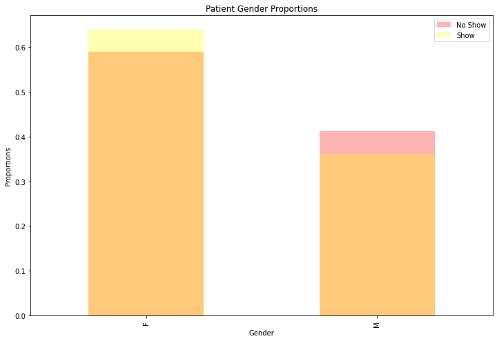

```python
# Compute the proportions
no_show_gender_proportions = no_show_patients.gender.value_counts() / no_show_patients.gender.count()
show_gender_proportions = show_patients.gender.value_counts() / show_patients.gender.count()
# Plot the proportions on the same figure.
plt.figure(figsize=(12, 8))
no_show_gender_proportions.plot(kind='bar', alpha=0.3, color='red', label='No Show')
show_gender_proportions.plot(kind='bar', alpha=0.3, color='yellow', label='Show')
plt.legend()
plt.xlabel('Gender')
plt.ylabel('Proportions')
plt.title('Patient Gender Proportions');
```

Looks like males tend to have more no show appointments than females. Let's also look at other patient properties and compare their mean statistics.

```python
no_show_properties = no_show_patients.drop(['patient_id', 'gender'], axis=1).mean()
show_properties = show_patients.drop(['patient_id', 'gender'], axis=1).mean()
# Compute the difference between patients who have no show appointment and patients
# who don't have no show appointments.
no_show_properties - show_properties
```

```
age              -2.932888
social_welfare    0.018378
hypertension     -0.024664
alcoholism        0.007825
diabetes         -0.007948
handicap          0.004792
dtype: float64
```

A few other observations:

- No show patients are approximately 3 years younger on average
- They tend to be more on social welfare
- They tend to have less hypertension and diabetes.
- They tend to have more alcoholism and handicap.

Let's see the trends of **social_welfare**, **hypertension**, **alcoholism**, **diabetes** and **handicap** with respect to age for all the patients.

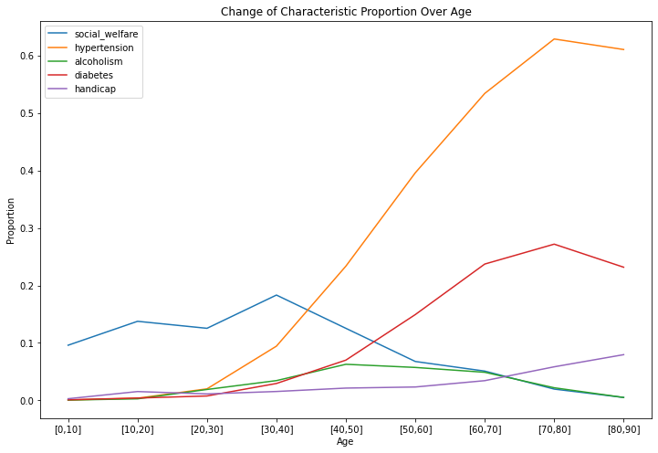

```python
# Merge the patients having and not having no show appointments.
all_patients = pd.concat([no_show_patients, show_patients], ignore_index=True).drop('patient_id', axis=1)
# Compute the bin labels for the age, in order to have more smooth curves for visualization
age_labels = ['[{},{}]'.format((i-1) * 10, i * 10) for i in range(1, 10)]
all_patients.age = pd.cut(all_patients.age, bins=9, labels=age_labels)
#Plot the rates with respect to age bins
all_patients.groupby('age').mean().plot(figsize=(12, 8))
plt.xlabel('Age')
plt.ylabel('Proportion')
plt.title('Change of Characteristic Proportion Over Age');
```

- People on social welfare tend to live in worse living conditions than people who are not on social welfare. Hence, I would expect them to live shorter. As patients age increase; the rate of patients who is on social welfare decreases. As no show patients are younger on average, they would also be more on social welfare; as, there are more people on social welfare for groups of young ages. This is what we observed in mean statistics.
- The results on preexisting conditions make sense. Hypertension and diabetes tend to be underlying conditions which appear when people get older. This is justified by the plot. Since, no show patients tend to be younger on average, it is expected that they would have less these preexisting conditions on average. This is what we observed in mean statistics.
- Although the no show patients have more alcoholism and handicaps; the plot doesn't justify the existing trend. Old people tend to have more handicaps due to physiological decay; which makes sense due to basic logic and the plot above. In addition, the no show patients are younger on avereage. So, I would expect that no show patients would have less handicaps. However, the mean statistics show otherwise, which is contradictory. This looks like a paradox; and, it is hard to conclude more on this. Similar paradoxal result is also observed for alcoholism. I would expect young patients having more alcoholism; as, alcoholic people tend to live shorter; and, there would be more alcoholic people among young patients. However, I can't see this trend in the plot; which contradicts the more alcoholism observed on average for no show patients who are younger on average.

### 2. Would the day and month of the scheduled appointment reflect on the no show?

Since the the columns other than the **no_show** and **scheduled_day** are irrelevant to answer this question, I will drop all the other columns.

```python
scheduled_df = clean_df[['scheduled_day', 'no_show']].copy(deep=True)
```

Next, I will extract the day of the week from the **scheduled_day** column.

```python
days = ['Monday', 'Tuesday', 'Wednesday', 'Thursday', 'Friday', 'Saturday', 'Sunday']
scheduled_df['day_of_week'] = scheduled_df.scheduled_day.dt.dayofweek.apply(lambda x: days[x])
```

I will also extract the month from the **scheduled_day**.

```python
scheduled_df['month'] = scheduled_df.scheduled_day.dt.month
```

Next, I will convert **no_show** column from categorical to numeric; 1 for "Yes" and 0 for "No". This way, I can compute the no show rate based on the day of the week and the month.

```python
scheduled_df.no_show = scheduled_df.no_show.replace(to_replace=['Yes', 'No'], value=[1, 0])
```

Let's first plot the no show rate for the appointments based on the day of the week.

```python
# Define function making bar plot, to be used in the remaineder of this question's analysis.
def make_bar_plot(series, xlabel, ylabel, title, color='red', figsize=(12, 8)):
    series.plot(kind='bar', figsize=figsize, color=color)
    plt.xlabel(xlabel)
    plt.ylabel(ylabel)
    plt.title(title);
```

First let's compute the no show rate for different time intervals, based on the day of week and the month.

```python
no_show_rate_per_day = scheduled_df.groupby('day_of_week').no_show.mean()
no_show_rate_per_month = scheduled_df.groupby('month').no_show.mean()
no_show_rate_combined = scheduled_df.groupby(['day_of_week', 'month']).no_show.mean()
```

Let's reorder the result of no show rate per day, based on the week of the day and plot a bar plot. Reordering is better for seeing the weekly trend more accurately.

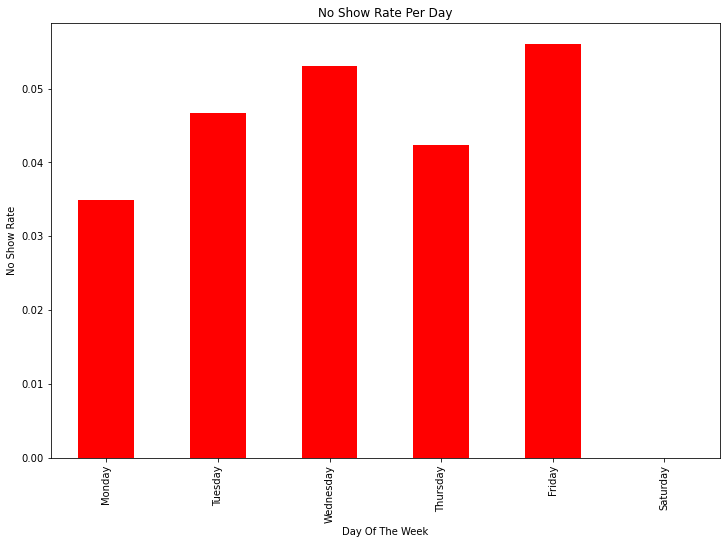

```python
# Define a new index, based on the ordered days.
idx = pd.Index(days[:-1])
# Use this index to sort the no show rate series based on the day of the week.
make_bar_plot(no_show_rate_per_day[idx], 'Day Of The Week', 'No Show Rate', 'No Show Rate Per Day')
```

A few quick observations:

- Everybody comes to their appointments on Saturday. Since this is weekend, it is normal and expected. People are not likely to have work related scheduling conflict.
- No show rates tend to increase towards Friday, in general.

What about month?

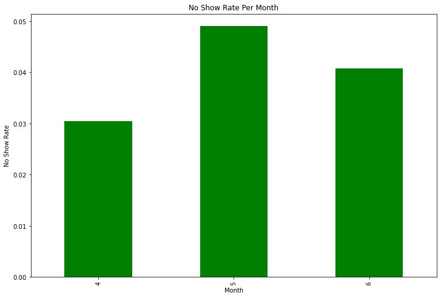

```python
make_bar_plot(no_show_rate_per_month, 'Month', 'No Show Rate', 'No Show Rate Per Month', 'green')
```

Our dataset only has visits from April until June; and, we have the highest no show rate on May. Hard to obtain more information.

Last, let's plot the day of the week and the month together to visualize the no show rate change.

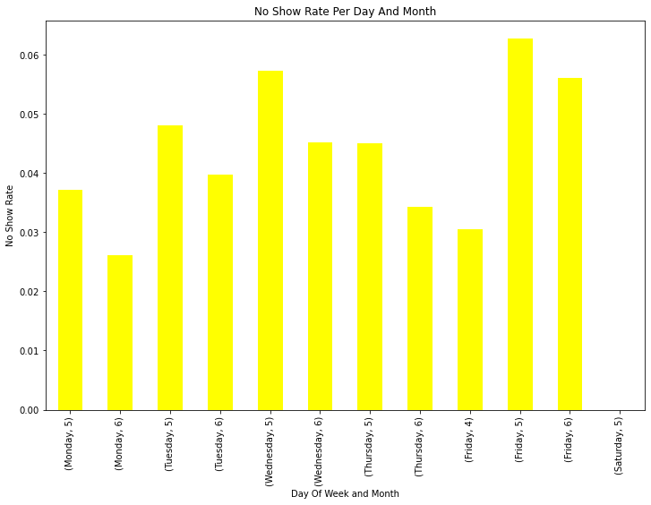

```python
make_bar_plot(no_show_rate_combined[idx], 'Day Of Week and Month', 'No Show Rate', 'No Show Rate Per Day And Month', 'yellow')
```

### 3. Would scheduling the appointment way more ahead than the actual appointment be related to more no show?

Let's compute the number of days between the **scheduled_day** and **appointment_day** for each appointment; and, compute the average number of days for no show and show appointments.

```python
appointment_df = clean_df[['scheduled_day', 'appointment_day', 'no_show']].copy(deep=True)
appointment_df['ahead'] = (appointment_df.scheduled_day - appointment_df.appointment_day).dt.days
appointment_df.groupby('no_show').ahead.mean()
```

```
no_show
No     0.000000
Yes    0.005593
Name: ahead, dtype: float64
```

Based on the computed descriptive statistics, there is not much difference in terms of the number of days in advance for no show appointments.

## Conclusions

Here, I tried to answer the following questions:

### What are the characteristics of patients who don't show up to their appointment?

Based on the computed descriptive statistics and the plots,

- Male patients tend to have more no show appointments than the female patients.
- Patients who have no show appointments are younger, on average, than the patients who don't have no show appointments.
- Patients who have no show appointments have lower diabetes and hypertension rates than the patients who don't have no show appointments.
- The diabetes and hypertension rates increase as the patients age increase, which conforms with the previous observation. As the patients having no show appointments are younger, they also have less these pre-existing conditions.
- Patients who have no show appointments have higher handicap and alcoholism rate.
- The handicap rate, however, increase as the patients age. This is expected as people's physiological condition decays due to aging. However, this is contradictory to the previous observation. As patients having no show appointment are younger than the patients in the other group, the handicap rate should have decreased instead; or, the handicap rate of patients having no show appointments should be less than the patients' not having no show appointments. This result is paradoxal and it is impossible to resolve without using causal inference.
- Similar paradoxal observation exists for alcoholism rates; and, it is also not possible to resolve this without causal inference.

### Would the day and month of the scheduled appointment reflect on the no show?

- Saturdays don't have no show appointments
- No show appointments occur more often from Monday to Friday
- May has the highest no show appointment rate
- May has the highest no show appointment rate for all the days of the week, which is consistent with the previous observation.

### Would scheduling the appointment way more ahead than the actual appointment be related to more no show?

There is not a remarkable difference in terms of the number of days between no show and show appointments. However, this is just based on the comparison of the statistics, without any statistical test. Thus, we can't claim any statistical significance for this.

### Analysis Shortcomings & Limitations

- Although the original dataset has 110527 examples, most of the data has incorrect entries in terms of the features **scheduled_day** and **appointment_day**. The **scheduled_day** should be after **appointment_day**. Moreover, the data has errant entries in other features. After cleaning the data from these mistakes, we end up with 38385 examples; so, more than half of the examples couldn't be included in our dataset.
- As more than half of the examples couldn't be included in the dataset, this hurts the representative power of the sample. All the appointments and patients analyzed are squashed between April 2016 and June 2016, which is a very short time interval.
- The data doesn't have missing values. The errant entries exist for a small number of examples for features **age** and **handicap**. Removing these examples wouldn't change significantly the analysis result. However, removing more than half of the data due to the incorrect **scheduled_day** and **appointment_day** entries affects the result a lot. Should these dates were correct and those examples were included, the analysis result would have been different; and, the sample would be more representative.
- We compare patients who have no show appointments with patients who don't have no show appointments in terms of **age**, **social_welfare**, **hypertension**, **alcoholism**, **diabetes**, **handicap**. The analysis here doesn't include any statistical test to compare the categories in a statistically significant way. Hence, this is the limitation of the analysis.
- Also, the analysis includes only the correlation between **age** and other categories among two groups of patients, show and no_show. There are some paradoxal results in terms of the comparison of these categories and their change over the patients. It is not possible to resolve these paradoxal observations without using confounding analysis or causal inference.
- The analysis could be improved by including the statistical tests for the comparison of categories **age**, **social_welfare**, **hypertension**, **alcoholism**, **diabetes**, **handicap**. The causal inference could be used to resolve some paradoxal observations for **alcoholism** and **handicap**.